```python
import pandas as pd
import numpy as np
import matplotlib.pyplot as plt
import seaborn as sns
#中文显示
plt.rcParams['font.sans-serif']=['SimHei']
plt.rcParams['axes.unicode_minus']=False
```

```python
data=pd.read_excel('D:\M\MATLAB Driver/forward/ninth\问卷数据-录入纸质.xlsx')
data.info()
```

```
<class 'pandas.core.frame.DataFrame'>
RangeIndex: 178 entries, 0 to 177
Data columns (total 26 columns):
 #   Column                         Non-Null Count  Dtype
---  ------                         --------------  -----
 0   序号                             178 non-null    int64
 1   您的年龄：                          178 non-null    int64
 2   您的性别：                          178 non-null    object
 3   您的文化程度：                        178 non-null    object
 4   您是否接受过疼痛知识宣教：                  178 non-null    object
 5   您目前身体健康程度：                     178 non-null    object
 6   您知道的疼痛分类包括哪些（多选）？              178 non-null    object
 7   您认为什么因素会导致疼痛（多选）？              178 non-null    object
 8   您认为以下哪种方法可以有效缓解疼痛（多选）？         178 non-null    object
 9   您在过去一年内感受到疼痛的频率是？              178 non-null    object
```

[output cut: 18 more lines]

# 一 认知现状

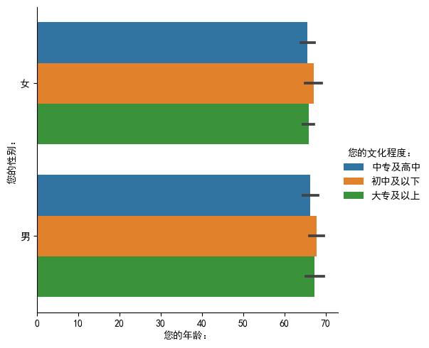

```python
#绘制您的年龄：与您的性别：与您的文化程度：的多变量图
sns.catplot(x='您的年龄：',y='您的性别：',hue='您的文化程度：',data=data,kind='bar')
```

问卷受众人群大多数60-70之间的老人且文化程度，男女分布相当。

首先分析对疼痛的看法类数据

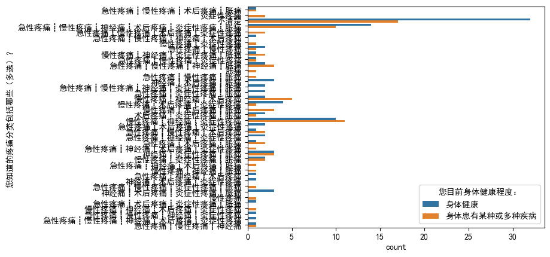

```python
#您知道的疼痛分类包括哪些（多选）？与您目前身体健康程度：因果绘图
sns.countplot(y='您知道的疼痛分类包括哪些（多选）？',hue='您目前身体健康程度：',data=data)
```

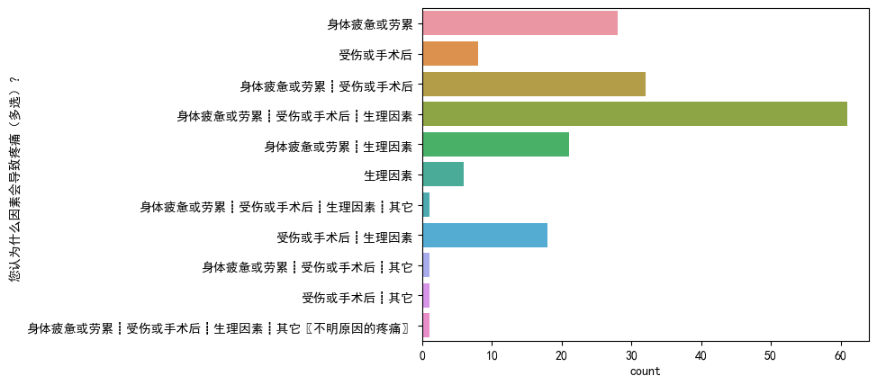

```python
#您认为什么因素会导致疼痛（多选）？绘图
sns.countplot(y='您认为什么因素会导致疼痛（多选）？',data=data)
```

[figure not shown]

```python
#您认为以下哪种方法可以有效缓解疼痛（多选）？绘图
sns.countplot(y='您认为以下哪种方法可以有效缓解疼痛（多选）？',data=data)
```

可见，大家对缓解疼痛的方法都有了解，应该是老人休闲时间多，以及大量生活经验。

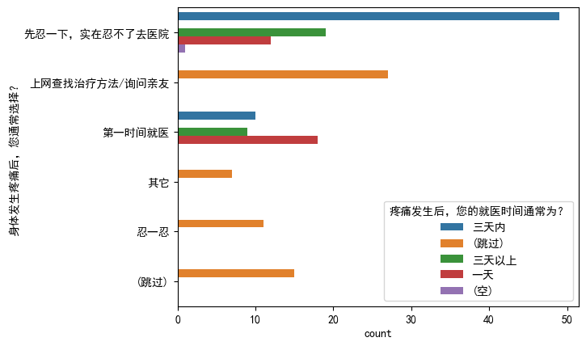

```python
# 身体发生疼痛后，您通常选择？	疼痛发生后，您的就医时间通常为？
sns.countplot(y='身体发生疼痛后，您通常选择？',hue='疼痛发生后，您的就医时间通常为？',data=data)
```

老年人看病拖延是一个很严重的问题，数据也表明了这一点。主要是对医院花费的恐惧，以及对医院的不信任。这是一个很严重的问题，需要引起重视。

# 对疼痛的看法

## 止痛药看法

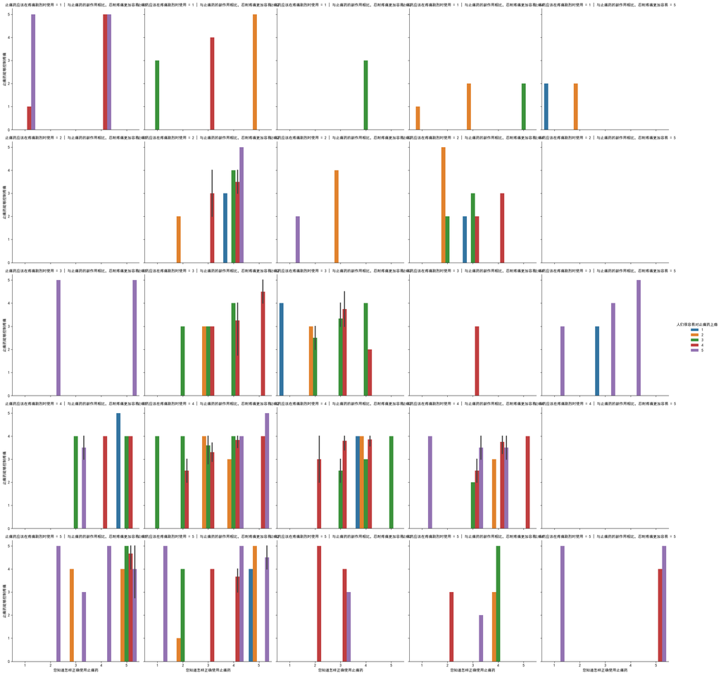

```python
#将所有的（1.非常不同意）替换成1，（2.不同意替）换成2，（3.一般）替换成3，（4.同意）替换成4，（5.非常同意）替换成5
data=data.replace('1.非常不同意',1)
data=data.replace('2.不同意',2)
data=data.replace('3.一般',3)
data=data.replace('4.同意',4)
data=data.replace('5.非常同意',5)
#您知道怎样正确使用止痛药与止痛药能够控制疼痛与人们很容易对止痛药上瘾与与止痛药的副作用相比，忍耐疼痛更加容易与止痛药应该在疼痛剧烈时使用多变量图
sns.catplot(x='您知道怎样正确使用止痛药',y='止痛药能够控制疼痛',hue='人们很容易对止痛药上瘾',col='与止痛药的副作用相比，忍耐疼痛更加容易',row='止痛药应该在疼痛剧烈时使用',data=data,kind='bar')
```

由此可见，图像数据主要集中在左下部分，表明大家对止痛药有一个清楚的认识，但比较少人会主动去了解止痛药的副作用。

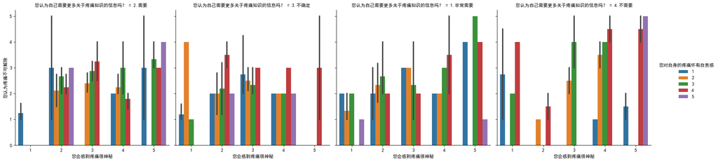

```python
#您会感到疼痛很神秘	您认为疼痛不可解除	您对自身的疼痛怀有自责感 您认为自己需要更多关于疼痛知识的信息吗？
sns.catplot(x='您会感到疼痛很神秘',y='您认为疼痛不可解除',hue='您对自身的疼痛怀有自责感',col='您认为自己需要更多关于疼痛知识的信息吗？',data=data,kind='bar')
```

从这里也能十分明了的看出大家对于疼痛有一定清楚认识，但仍然有许多渴望了解更多疼痛知识的人。而且对自身的疼痛感怀有一定责任感的人也是占大多数的。由此看来大家对此是抱有积极态度的

# 参与相关医疗活动

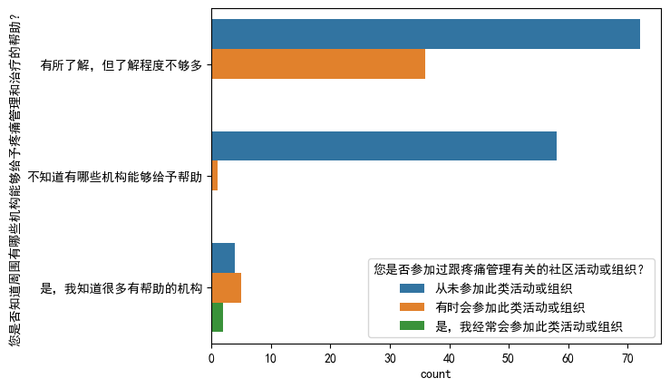

```python
#您是否知道周围有哪些机构能够给予疼痛管理和治疗的帮助？	您是否参加过跟疼痛管理有关的社区活动或组织？	您认为自己需要哪些形式的信息和资源来了解疼痛知识（多选）？绘图
sns.countplot(y='您是否知道周围有哪些机构能够给予疼痛管理和治疗的帮助？',hue='您是否参加过跟疼痛管理有关的社区活动或组织？',data=data)
```

老年人大多喜欢休闲活动，所以经常会了解许多医疗活动，但是参与的人数却很少，这可能是因为老年人的身体状况不允许，或者是老年人的思想观念，害怕上当等因素。

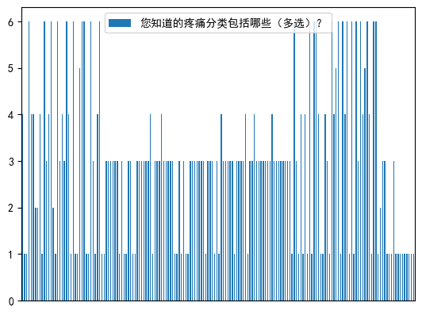

```python
#您知道的疼痛分类包括哪些（多选）？每行按┋进行分割然后计算数量
t1=data['您知道的疼痛分类包括哪些（多选）？'].str.split('┋')
#将”不清楚“替换成0
t1=t1.replace('不清楚',0)
#将t1转换成dataframe
t1=pd.DataFrame(t1)
#对t1每行进行分别统计字符个数，0还是0，其他的就是字符个数
t1=t1.applymap(lambda x: len(x) if x!=0 else 0)
#绘图t1，取消x轴的标签
t1.plot(kind='bar',xticks=[])
```

# 二 影响因素

对疼痛知识的认知情况及影响因素中的“影响因素”侧重点在于影响老人认知疼痛的外在与内在因素，例如经济，心理，社会状况等。即问卷中的数据能从侧面反应问题。

```python
# 疼痛对健康有影响	您知道怎样正确使用止痛药	止痛药能够控制疼痛	人们很容易对止痛药上瘾	与止痛药的副作用相比，忍耐疼痛更加容易	止痛药应该在疼痛剧烈时使用
#将这几列进行组合成一个新的dataframe，命名为data1
data1=data[['疼痛对健康有影响','您知道怎样正确使用止痛药','止痛药能够控制疼痛','人们很容易对止痛药上瘾','与止痛药的副作用相比，忍耐疼痛更加容易','止痛药应该在疼痛剧烈时使用']]
```

[output not shown]

178 rows × 6 columns

```python
#计算data1的相关系数
data1.corr()
```

|  | 疼痛对健康有影响 | 您知道怎样正确使用止痛药 | 止痛药能够控制疼痛 | 人们很容易对止痛药上瘾 | 与止痛药的副作用相比，忍耐疼痛更加容易 | 止痛药应该在疼痛剧烈时使用 |
| --- | --- | --- | --- | --- | --- | --- |
| 疼痛对健康有影响 | 1.000000 | 0.390428 | 0.491381 | 0.430127 | -0.340700 | 0.440748 |
| 您知道怎样正确使用止痛药 | 0.390428 | 1.000000 | 0.367918 | 0.099744 | -0.241502 | 0.274676 |
| 止痛药能够控制疼痛 | 0.491381 | 0.367918 | 1.000000 | 0.252443 | -0.304778 | 0.322574 |
| 人们很容易对止痛药上瘾 | 0.430127 | 0.099744 | 0.252443 | 1.000000 | -0.134919 | 0.269980 |
| 与止痛药的副作用相比，忍耐疼痛更加容易 | -0.340700 | -0.241502 | -0.304778 | -0.134919 | 1.000000 | -0.194193 |
| 止痛药应该在疼痛剧烈时使用 | 0.440748 | 0.274676 | 0.322574 | 0.269980 | -0.194193 | 1.000000 |

这几种变量的相关性都不强，但是可以看出，在使用止痛药副作用与忍耐疼痛相比下，更倾向于忍耐疼痛。与此情况下所反应的是使用疼痛药的耗资情况与老人的讳疾忌医心理。

```python
#您会感到疼痛很神秘	您认为疼痛不可解除	您对自身的疼痛怀有自责感	您认为自己需要更多关于疼痛知识的信息吗？
#将这几列进行组合成一个新的dataframe，命名为data2
data2=data[['您对自身的疼痛怀有自责感','您认为疼痛不可解除','您会感到疼痛很神秘']]
#计算data2的相关系数
data2.corr()
```

|  | 您对自身的疼痛怀有自责感 | 您认为疼痛不可解除 | 您会感到疼痛很神秘 |
| --- | --- | --- | --- |
| 您对自身的疼痛怀有自责感 | 1.000000 | 0.277348 | 0.340501 |
| 您认为疼痛不可解除 | 0.277348 | 1.000000 | 0.371914 |
| 您会感到疼痛很神秘 | 0.340501 | 0.371914 | 1.000000 |

同样，对疼痛的理解不到位，畏惧疼痛也影响了疼痛认知缺失的情况。

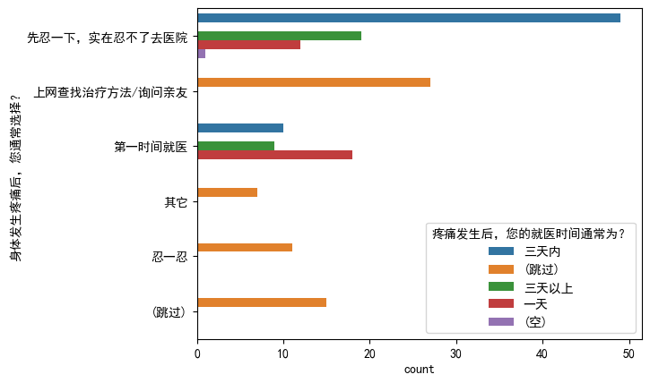

```python
# 身体发生疼痛后，您通常选择？	疼痛发生后，您的就医时间通常为？绘制关系图
sns.countplot(y='身体发生疼痛后，您通常选择？',hue='疼痛发生后，您的就医时间通常为？',data=data)
```

# 经济情况应该是最能影响疼痛认知的因素之一，大部分老人的经济来源是退休金，而面对医院的高昂费用，很多老人会选择忍受疼痛，而不去医院就医。强行忍耐。

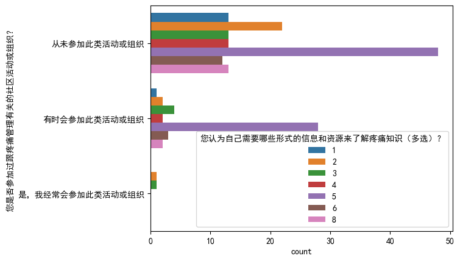

```python
#您认为自己需要哪些形式的信息和资源来了解疼痛知识（多选）？
#将这一列进行分割，按┋进行分割
t2=data['您认为自己需要哪些形式的信息和资源来了解疼痛知识（多选）？'].str.split('┋')
#将t2转换成dataframe
t2=pd.DataFrame(t2)
#将“其他”替换为0
t2=t2.replace('其他',0)
#对t2每行进行分别统计字符个数，其他替换为0，其他的就是字符个数
t2=t2.applymap(lambda x: len(x) if x!=0 else 0)
#绘图t2柱状图
sns.countplot(y='您是否参加过跟疼痛管理有关的社区活动或组织？',hue=t2['您认为自己需要哪些形式的信息和资源来了解疼痛知识（多选）？'],data=data)
```

经常参加活动的人很少需要其他形式来了解疼痛知识，而从未参加的却十分渴望了解疼痛知识，这可能是因为经常参加活动的人已经了解了疼痛知识，并且更能够身临其境。而未参加的可能是因为身体原因，或者是思想观念等，不愿意参加活动，害怕上当。